# Intro_to_R_live_Part2_key

Jess Hoffman

11/4/2020

Part 2 will cover a few important and frequently used plots for biological data: histograms, volcano plots, PCA plots, and heatmaps.

## 0. Load Packages

```r
library(plyr)
library(tidyverse)

# make sure you also set your working directory to load in the part2 data:
# setwd("~/GitHub/DVAC_Nov_2020_intro_R_and_ggplot") # replace with your path to the DVAC cloned folder
```

## 1. Histogram

Histograms show frequency distributions, or how often each value occurs in a data set. Histograms are can be used to identify outliers and determine the shape of distribution (ex. skew left/right, unimodal, bimodal, etc.)

For this example, I'm using log-transformed microarray data from 3 samples: E1, E2, E3. We will first munge the data with pivot_longer so that it's in tidy format (one variable per column).

```r
setwd("~/Documents/DVAC_Nov_2020_intro_R_and_ggplot")
RNA = read_csv("data/part2/microarray.csv") #read in data
# data munging --> pivot longer
RNA_long <- RNA %>%
  pivot_longer(
    contains("E"), #combine columns with "E" in the name
    names_to = "Sample", #put sample names in one column
    values_to = "value", #put values in its own column
    names_prefix = "E") #cutoff E

mu <- ddply(RNA_long, "Sample", summarise, smean=mean(value))
head(mu) #get sample means
```

```
##   Sample smean
## 1      1    NA
## 2      2    NA
## 3      3    NA
```

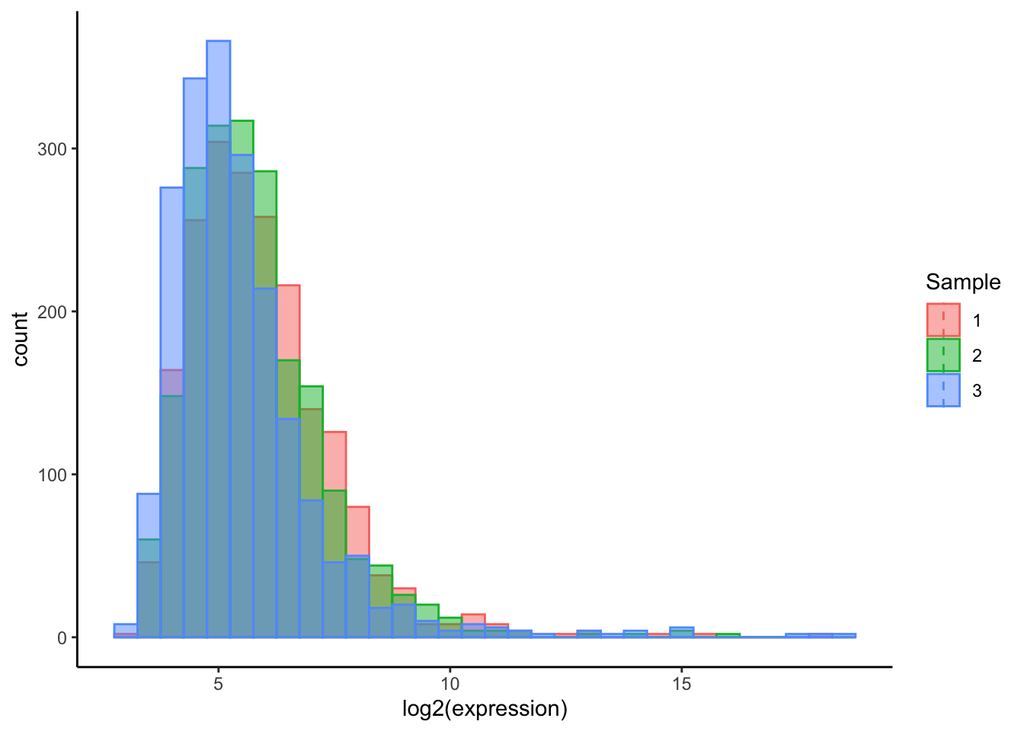

```r
ggplot(data = RNA_long, aes(x=value, color=Sample, fill=Sample)) + #color by sample label
  geom_histogram(binwidth=0.5, alpha=0.5, position="identity") + #identity = overlapped look, alpha = color opacity
  xlab("log2(expression)")+
  theme_classic()+
  geom_vline(data=mu, aes(xintercept=smean, color=Sample), linetype="dashed")
```

```r
# These data are similarily distributed, skewed right
```

## 2. Heatmap

Illustrate data by color.

In this example, my dataset is from an animal myocardial infarction (MI) model. There are two treatment groups: placebo & drug treatment, and two tissue areas: border zone (BZ) and infarct zone (IZ). These values are pre-filtered and normalized. The heatmap will display differences in gene expression amongst these groups and we will get unsupervised clustering of the samples.

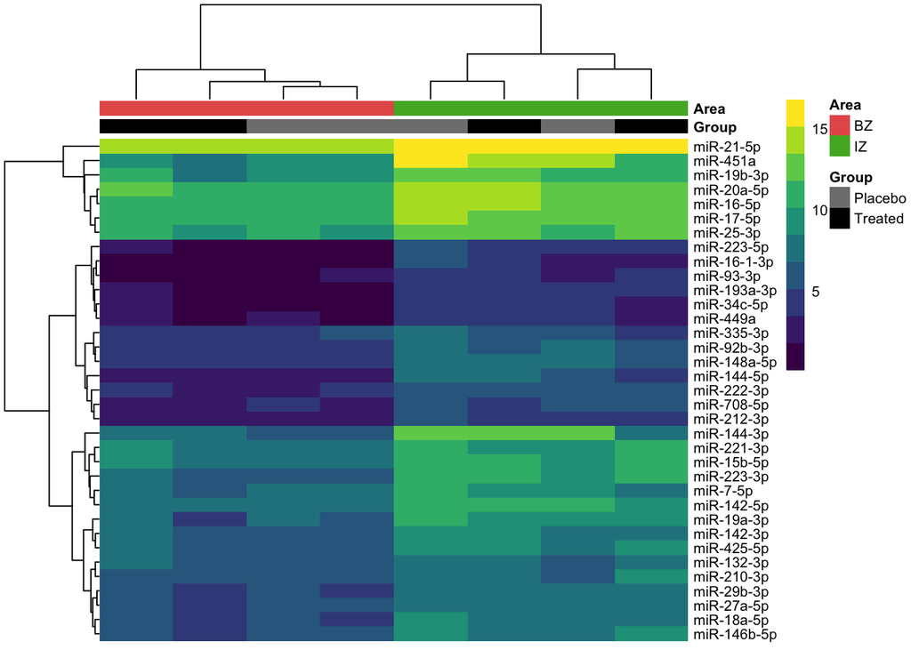

```r
setwd("~/Documents/DVAC_Nov_2020_intro_R_and_ggplot")
library(pheatmap) #best heatmap package available (imo). Super customizable.
library(viridis) #color scheme
MI = read.csv("data/part2/acuteMI.csv") #read in data
rownames(MI) = MI[,1]; MI = MI[,2:ncol(MI)] #make the miRNA names the row names

area = c("BZ","BZ","IZ","IZ","BZ","BZ","IZ","IZ")
group = c(rep("Placebo",4), rep("Treated", 4))

# data munging
groups = data.frame(Group = group, Area = area)
rownames(groups) = colnames(MI)

#color code the sample location and treatment group:
annotation_colors = list(Group = c(Placebo="gray50", Treated="black"), Area = c(BZ="#E55C58", IZ="#51B12C"))

pheatmap(MI,
         cluster_rows = T, #cluster the microRNAs
         cluster_cols = T, #cluster the samples
         color = viridis(10), #set the heatmap color ranage, 10 colors on the viridis scale
         show_rownames = TRUE,
         show_colnames = FALSE,
         border_color = NA, #remove grey square around boxes
         annotation_col = groups, #annotation dataframe
         annotation_colors = annotation_colors, #colors in the annotation bars
         fontsize = 8)
```

## 3. PCA

Principal component analysis (PCA) is a dimensionality-reduction method. It takes large datasets and transforms them to 2 or 3 components so the data may be illustrated and interpreted. PCA is often used to see how samples cluster.

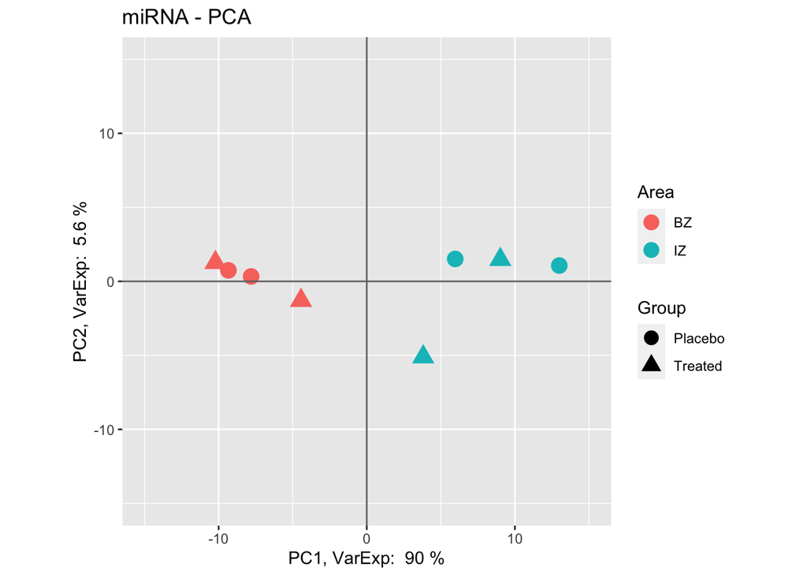

```r
PCA <- prcomp(t(MI)) #calculate principal components, samples must be listed as rows so use the transpose, t(), function.
percentVar <- round(100*PCA$sdev^2/sum(PCA$sdev^2),1) #Calculate what percent of variance each PC describes

dataGG <- data.frame(PC1 = PCA$x[,1], PC2 = PCA$x[,2], #setup plotting dataframe with first 2 components
                     Sample = colnames(MI),
                     Area = area,
                     Group = group)

ggplot(dataGG, aes(PC1, PC2)) + #plot 1st 2 components
  geom_point(aes(shape = Group, colour = Area, size = 2)) + #color by heart section and shape by treatment group
  guides(size = FALSE, color = guide_legend(override.aes = list(size=4)), shape = guide_legend(override.aes = list(size=4)))+ #Alter the legend, remove size and increase the points in the area and group legend
  ggtitle("miRNA - PCA") + #give it a title
  xlab(paste("PC1, VarExp: ", percentVar[1], "%")) + #concatenate strings with the % Var described
  ylab(paste("PC2, VarExp: ", percentVar[2], "%")) +
  xlim(-15,15) + #set axis bounds
  ylim(-15,15) +
  theme(aspect.ratio=1) + #square plot
  geom_hline(yintercept=0, color = "gray45", size=0.5) + #set intercept lines
  geom_vline(xintercept=0, color = "gray45", size=0.5)
```

## Volcano plot

Volcano plots are scatterplots which show statistical significance vs. foldchange. We often use these to show up and downregulated genes/proteins between 2 experimental groups.

These data are the differences between tissue sections in the treatment group from the MI data.

```r
setwd("~/Documents/DVAC_Nov_2020_intro_R_and_ggplot")
library(ggrepel) #has extra features for ggplot2. We use it here to label points in the plot.

vp <- read_csv("data/part2/volcanoex.csv") #data frame with microRNA, p-value, -log10(p-value), and log2(fc)
head(vp)
```

```
## # A tibble: 6 x 4
##   id               p.value logp.value log2fc
##   <chr>              <dbl>      <dbl>  <dbl>
## 1 hsa-miR-92a-1-5p  0.012       1.92  -1.6
## 2 hsa-miR-144-3p    0.02        1.70  -1.2
## 3 hsa-miR-449a      0.04        1.40  -1
## 4 hsa-miR-30c-1-3p  0.0655      1.18  -0.8
## 5 hsa-miR-15b-3p    0.605       0.219 -0.254
## 6 hsa-miR-17-3p     0.650       0.187 -0.236
```

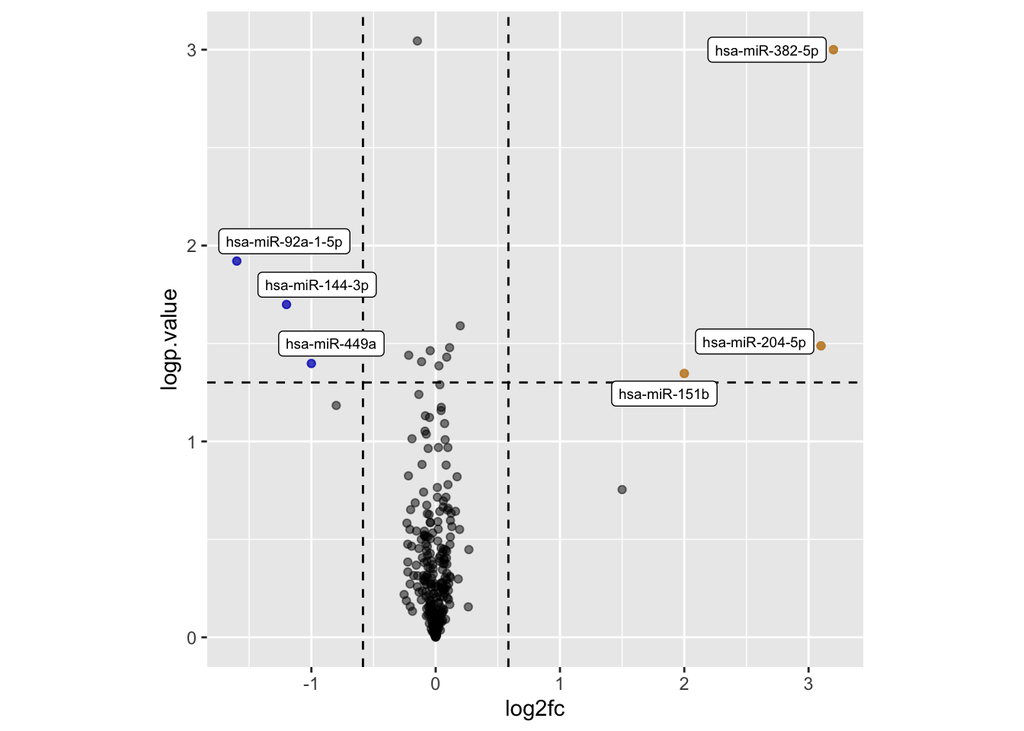

```r
vp %>%  # you can use the tidyverse pipe instead of data=vp. Just another option
  ggplot(aes(log2fc, logp.value))+ #plot fc vs. p
  geom_point(alpha = .5)+ #point transparency
  geom_point(data = filter(vp, log2fc < -log2(1.5) & p.value < 0.05), color = "blue", alpha = 0.5)+ #color miRs with p<0.05 and fc<-1.5 blue
  geom_point(data = filter(vp, log2fc > log2(1.5) & p.value < 0.05), color = "orange", alpha = 0.5)+
  geom_hline(yintercept = -log10(0.05), linetype = 2)+ #put horizontal line at p=0.05
  geom_vline(xintercept = c(-log2(1.5),log2(1.5)), linetype = 2)+ #put vertical lines at |fc|=1.5
  geom_label_repel(data = vp %>% #label points
                     filter(log2fc >= log2(1.5) & p.value < 0.05) %>% #filter to significant points
                     arrange(desc(log2fc)) %>%
                     slice(1:30),
                   aes(label = id),
                   size = 2.5,
                   segment.alpha = 0.5)+
  geom_label_repel(data = vp %>%
                     filter(log2fc <= -log2(1.5) & p.value < 0.05) %>%
                     arrange(log2fc) %>%
                     slice(1:30),
                   aes(label = id),
                   size = 2.5) +
  theme(aspect.ratio=1) #set plot to square area
```